# Line_Chart_Tutorial

Raquel Baltazar

Mon 04 Jan 2021 (15:31:48)

# Line Charts with R

*Source:* https://appsilon.com/ggplot2-line-charts/

```r
library(dplyr)
```

```r
library(ggplot2)
library(gapminder)
head(gapminder)
```

```
## # A tibble: 6 x 6
##   country     continent  year lifeExp      pop gdpPercap
##   <fct>       <fct>     <int>   <dbl>    <int>     <dbl>
## 1 Afghanistan Asia       1952    28.8  8425333      779.
## 2 Afghanistan Asia       1957    30.3  9240934      821.
## 3 Afghanistan Asia       1962    32.0 10267083      853.
## 4 Afghanistan Asia       1967    34.0 11537966      836.
## 5 Afghanistan Asia       1972    36.1 13079460      740.
## 6 Afghanistan Asia       1977    38.4 14880372      786.
```

# Make your first line chart

Your first chart will show the population over time for the United States. Columns `year` and `pop` are placed on X-axis and Y-axis, respectively:

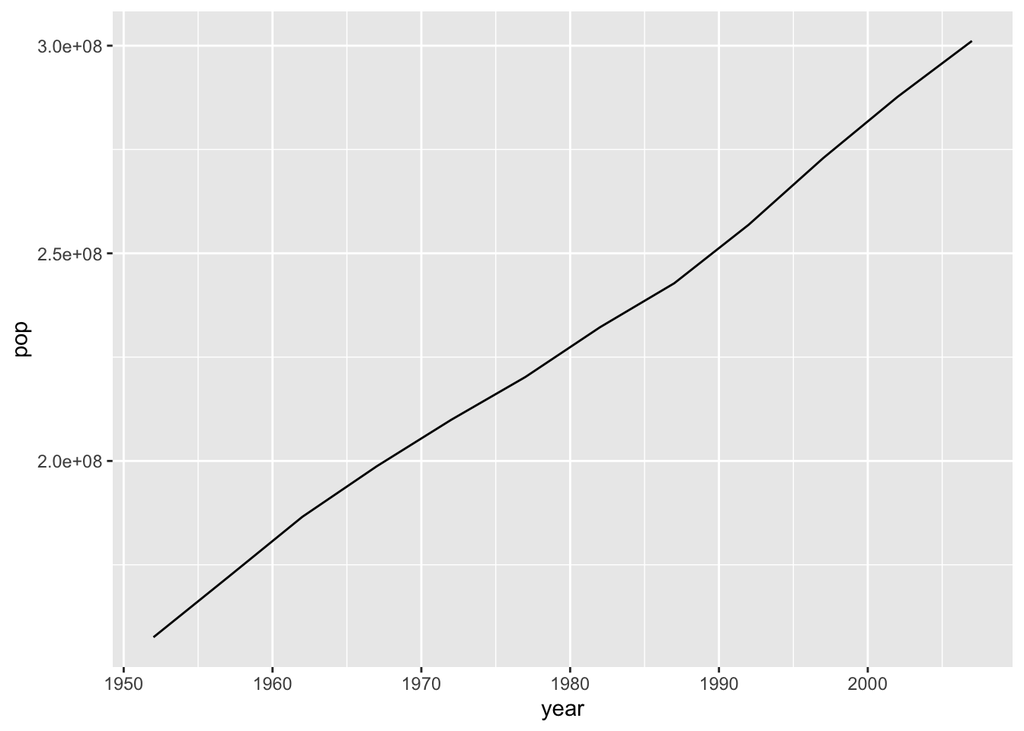

```r
usa <- gapminder %>%
  filter(continent == "Americas", country == "United States")

ggplot(usa, aes(x = year, y = pop)) +
  geom_line()
```

# Change Color, Line Type, and Add Markers

With the `geom_line()` layer, you can change the following properties:

- color – line color
- size – line width
- linetype – maybe you want dashed lines

**Make a thicker dashed blue line:**

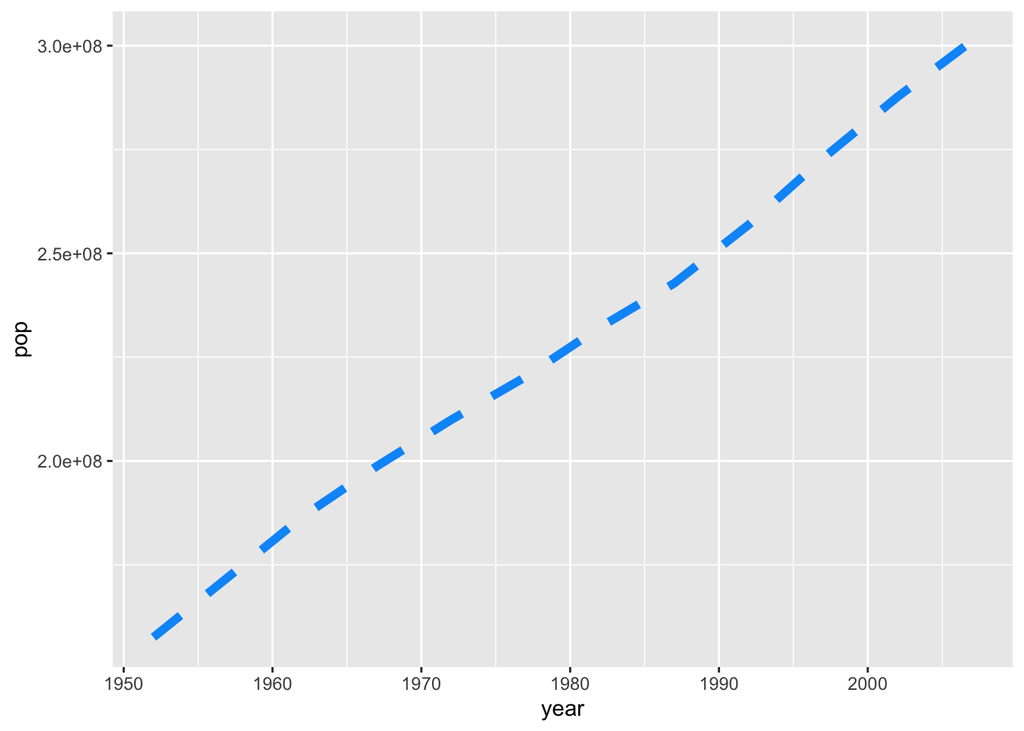

```r
ggplot(usa, aes(x = year, y = pop)) +
  geom_line(linetype = "dashed", color = "#0099f9", size = 2)
```

**Now add points (markers):**

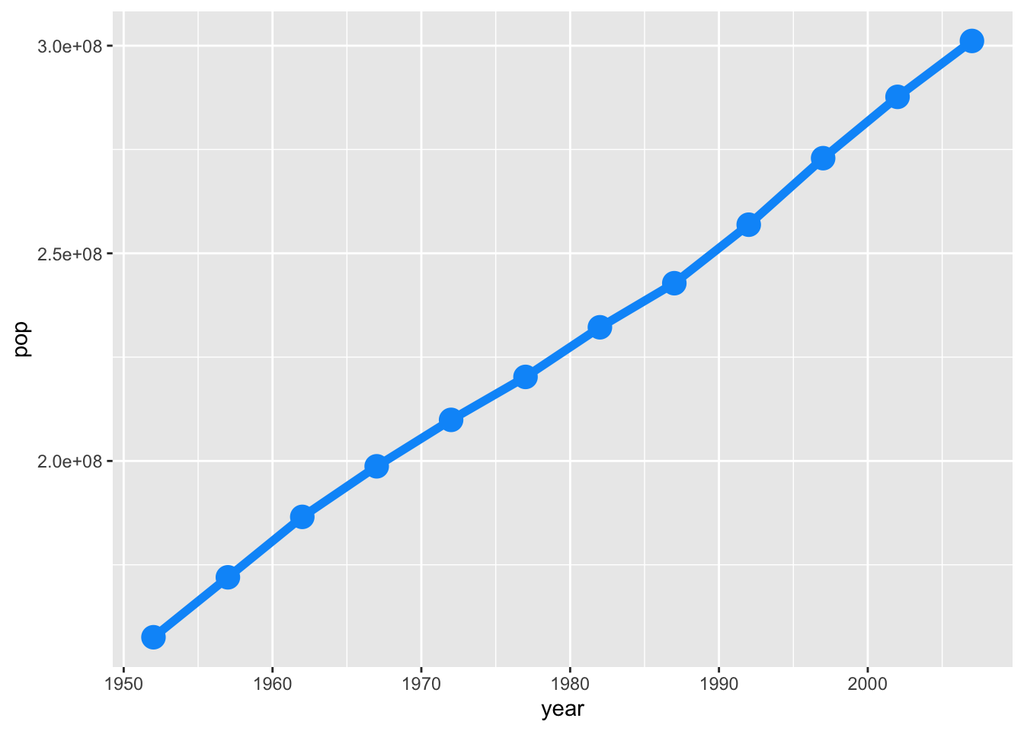

```r
ggplot(usa, aes(x = year, y = pop)) +
  geom_line(color = "#0099f9", size = 2) +
  geom_point(color = "#0099f9", size = 5)
```

# Titles, Subtitles, and Captions

You can add titles and subtitles through a `labs()` layer. It takes in values for **title**, **subtitle**, and **caption**.

**Add all three:**

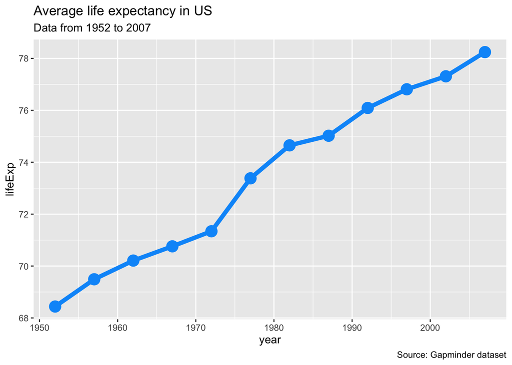

```r
ggplot(usa, aes(x = year, y = lifeExp)) +
  geom_line(color = "#0099f9", size = 2) +
  geom_point(color = "#0099f9", size = 5) +
  labs(
    title = "Average life expectancy in US",
    subtitle = "Data from 1952 to 2007",
    caption = "Source: Gapminder dataset")
```

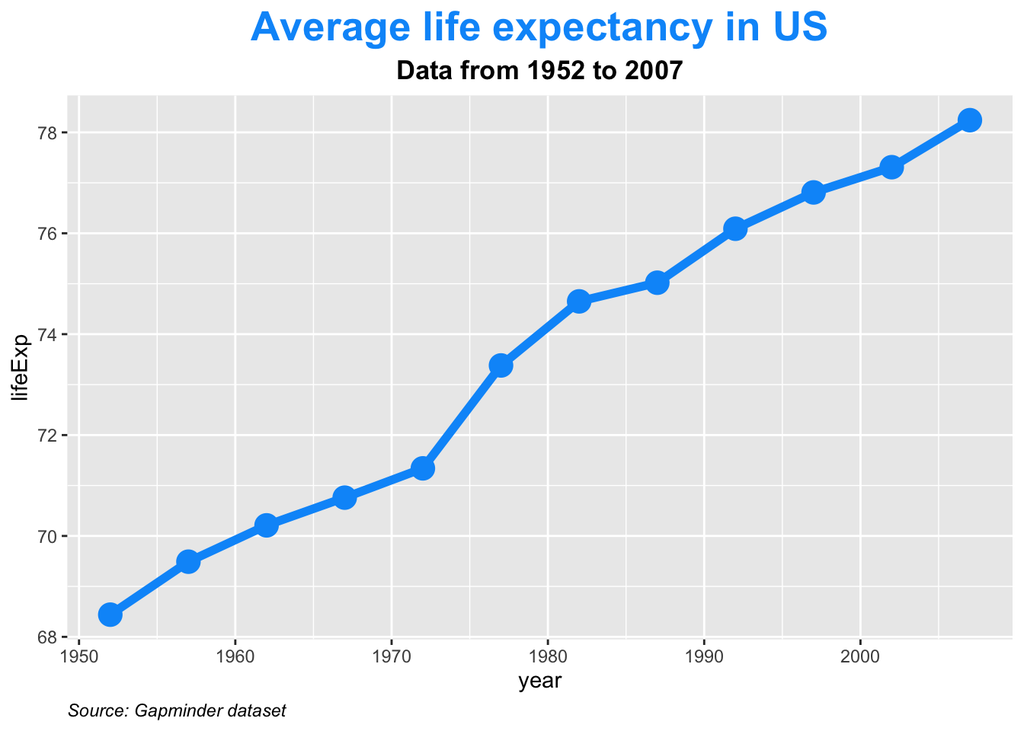

```r
ggplot(usa, aes(x = year, y = lifeExp)) +
  geom_line(color = "#0099f9", size = 2) +
  geom_point(color = "#0099f9", size = 5) +
  labs(
    title = "Average life expectancy in US",
    subtitle = "Data from 1952 to 2007",
    caption = "Source: Gapminder dataset") +
  theme(
    plot.title = element_text(color = "#0099f9", size = 20, face = "bold", hjust = 0.5),
    plot.subtitle = element_text(size = 13, face = "bold", hjust = 0.5),
    plot.caption = element_text(face = "italic", hjust = 0))
```

# Edit Axis Labels

Just take a look at the Y-axis for the previous year vs. population charts. The ticks look horrible. Scientific notation doesn’t help make things easier to read. The following snippet puts “M” next to the number – indicates “Millions”:

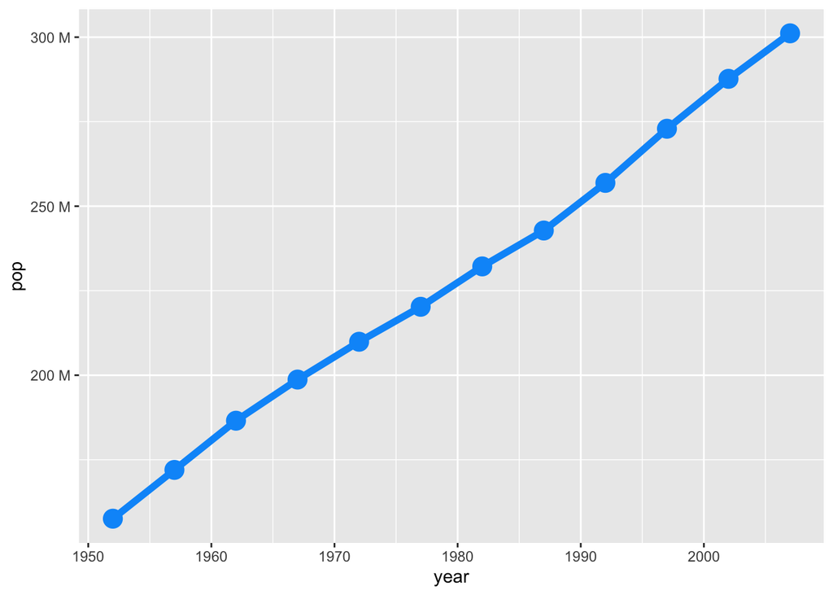

```r
library(scales)

ggplot(usa, aes(x = year, y = pop)) +
  geom_line(color = "#0099f9", size = 2) +
  geom_point(color = "#0099f9", size = 5) +
  scale_y_continuous(
    labels = unit_format(unit = "M", scale = 1e-6))
```

Let’s add **more space on top and bottom**. You can specify where the axis starts and ends:

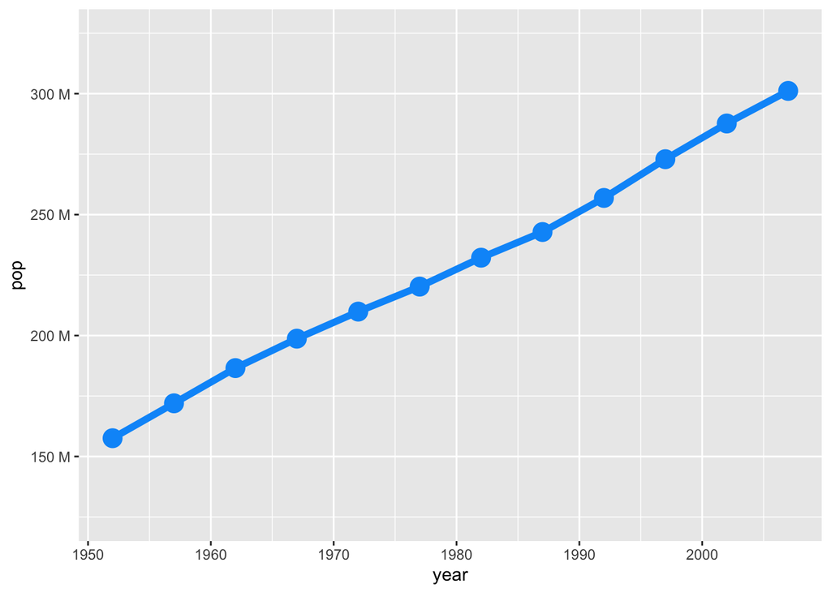

```r
ggplot(usa, aes(x = year, y = pop)) +
  geom_line(color = "#0099f9", size = 2) +
  geom_point(color = "#0099f9", size = 5) +
  expand_limits(y = c(125000000, 325000000)) +
  scale_y_continuous(
    labels = unit_format(unit = "M", scale = 1e-6))
```

Use the `labs()` layer to take in values for `x` and `y` – these determine the text shown on the X and Y axes, respectively. You can tweak the styles for axis labels the same way you did with the title, subtitle, and caption. This is how:

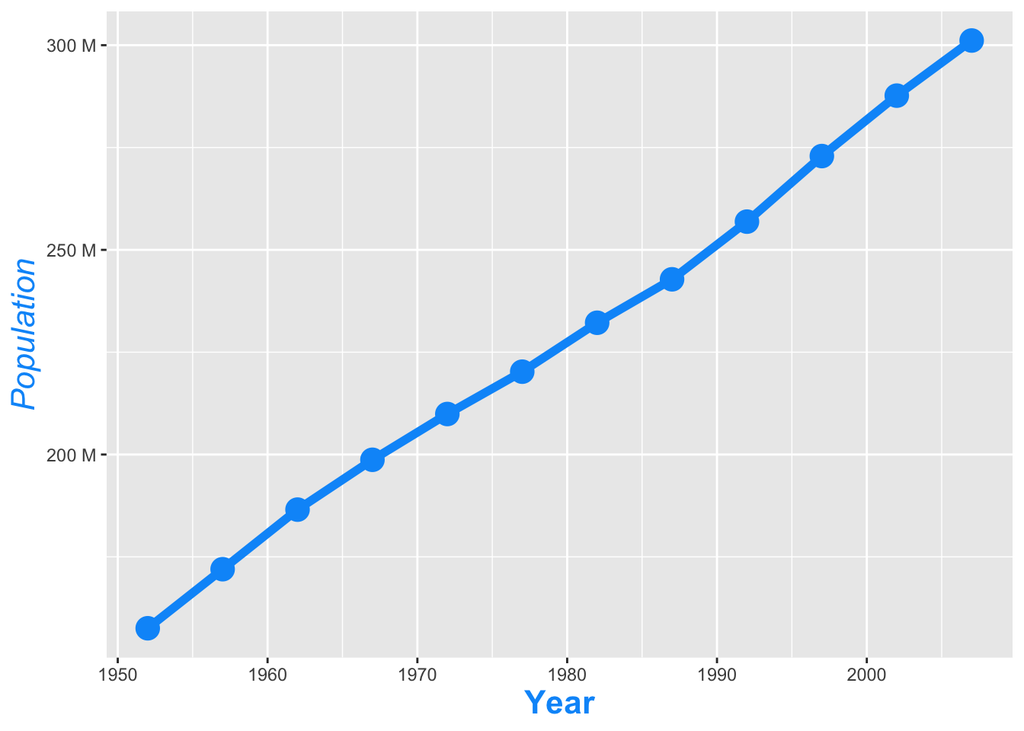

```r
ggplot(usa, aes(x = year, y = pop)) +
  geom_line(color = "#0099f9", size = 2) +
  geom_point(color = "#0099f9", size = 5) +
  scale_y_continuous(
    labels = unit_format(unit = "M", scale = 1e-6)) +
  labs(
    x = "Year",
    y = "Population") +
  theme(
    axis.title.x = element_text(color = "#0099f9", size = 16, face = "bold"),
    axis.title.y = element_text(color = "#0099f9", size = 16, face = "italic"))
```

# Draw Multiple Lines on the Same Chart

Here we will show multiple lines on a single chart. We’ll compare average life expectancy between major North American countries – the United States, Canada, and Mexico.

**You can use the `group` attribute in the data aesthetics layer to display multiple lines.** Here’s how:

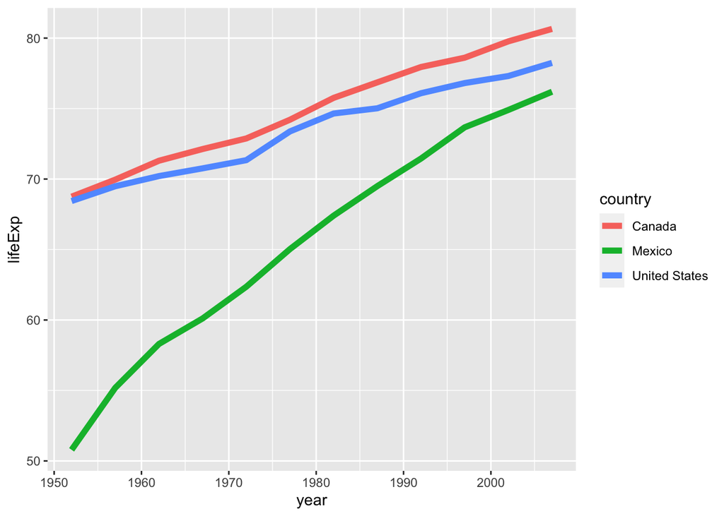

```r
north_big <- gapminder %>%
  filter(continent == "Americas", country %in% c("United States", "Canada", "Mexico"))

ggplot(north_big, aes(x = year, y = lifeExp, group = country)) +
  geom_line(aes(color = country), size = 2)
```

like above (the single line), you can add **markers** to multiple lines. Here is how:

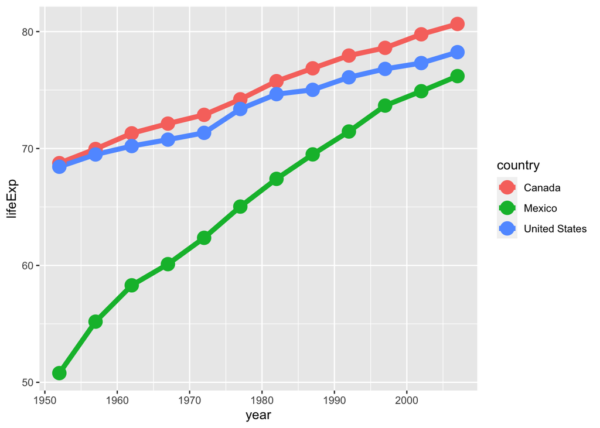

```r
ggplot(north_big, aes(x = year, y = lifeExp, group = country)) +
  geom_line(aes(color = country), size = 2) +
  geom_point(aes(color = country), size = 5)
```

**the legend on the right appears whenever you have multiple lines in one chart in order to know which is which**

But, let’s put the legend on the top:

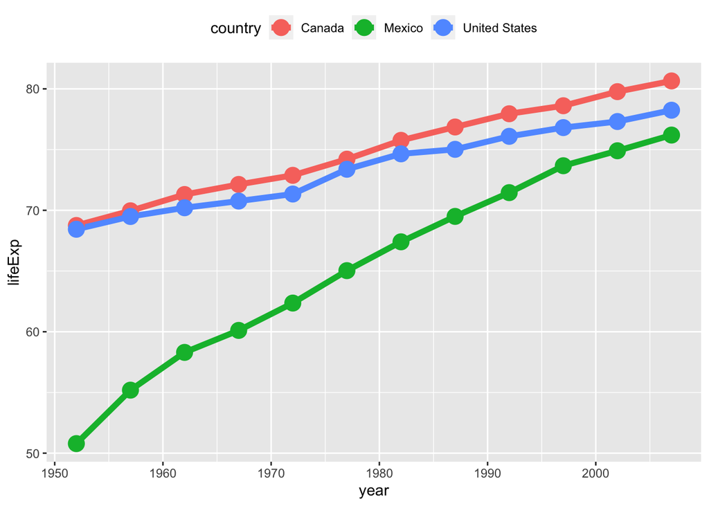

```r
ggplot(north_big, aes(x = year, y = lifeExp, group = country)) +
  geom_line(aes(color = country), size = 2) +
  geom_point(aes(color = country), size = 5) +
  theme(legend.position = "top")
```

# Adding Labels

**Be mindful that your labels do not make your visualisation messy**

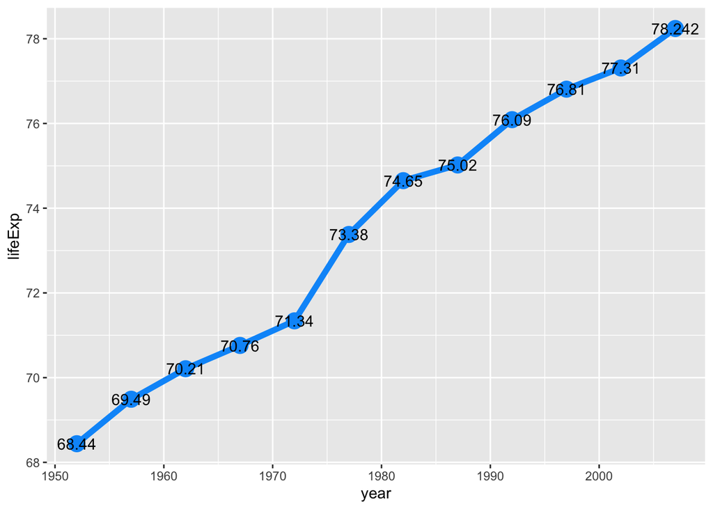

```r
ggplot(usa, aes(x = year, y = lifeExp)) +
  geom_line(color = "#0099f9", size = 2) +
  geom_point(color = "#0099f9", size = 5) +
  geom_text(aes(label = lifeExp))
```

Here you can make the text larger and push the labels a bit higher:

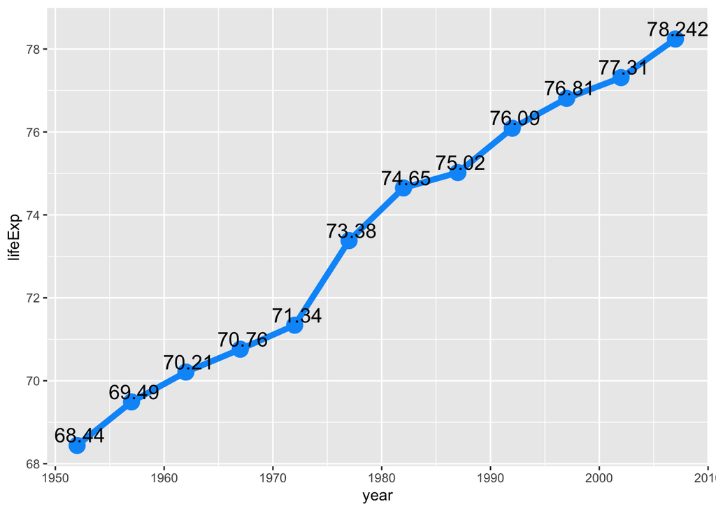

```r
ggplot(usa, aes(x = year, y = lifeExp)) +
  geom_line(color = "#0099f9", size = 2) +
  geom_point(color = "#0099f9", size = 5) +
  geom_text(
    aes(label = lifeExp),
    nudge_x = 0.25,
    nudge_y = 0.25,
    check_overlap = TRUE,
    size = 5)
```

Showing text might not be the cleanest solution every time.

Let’s wrap the text inside a box to give your visualization a touch more style. You can do that by replacing `geom_text()` with `geom_label()`. That’s the only change you need to make:

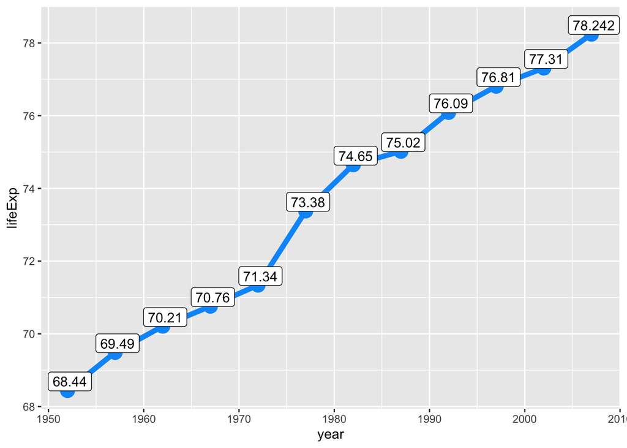

```r
ggplot(usa, aes(x = year, y = lifeExp)) +
  geom_line(color = "#0099f9", size = 2) +
  geom_point(color = "#0099f9", size = 5) +
  geom_label(
    aes(label = lifeExp),
    nudge_x = 0.25,
    nudge_y = 0.25,
    check_overlap = TRUE
  )
```